# Diamond Price Estimation

Ebru Gecici

06 09 2020

# 1 Diamonds

Diamonds are the hardest element found in nature and their atoms are arranged crystal structure. Moreover, diamonds are one of the most popular and preferable jewelry. They, on the other hand, are one of the most expensive jewelry. Thus, the characteristics of the diamond are very important to define price. According to the [Yadav Diamond](https://www.yadavjewelry.com/info/diamond-education/your-complete-diamond-characteristics-guide#:~:text=Actually%20diamond%20has%20four%20main,they%20affect%20the%20diamond's%20price.) information, there are four important features. They are called *4C*. Especially, these 4C’s of diamond constitutes the vast majority of the price.

- **Carat**: The carat is the weight of the diamond and this weight is important for the diamond
  - One carat is equal to 1/5 of a gram
  - One carat is divided into a hundred equal points
- **Color**: This feature give the color feature into the diamond.
  - Grade range of D to F has colorless diamonds. Moreover, the value of these type of diamonds is higher than the others
  - Diamonds, which have lower than F, are also shine. But these diamonds have strong color tones
  - A factor which is related with color is named as Fluorescence which is caused by boron trace amount inside the diamond. Fluorescence is activated by ultraviolet light. It is believed that a diamond with intense fluorescence has positive effect.
  - [Colors](https://www.bluenile.com/education/diamonds/color):
    - Colorless Diamonds,the rarest and highest quality with a pure icy look, **D-F Color Diamonds**
    - Near-colorless diamonds: No discernible color; great value for the quality, **G-H Color Diamonds** and **I-J Color Diamonds**
    - Faint color diamonds: Budget-friendly pick; pairs beautifully with yellow gold, **K Color Diamonds**

[figure not shown]

Figure 1. Color classification of the diamonds

- **Clarity**: Clarity defines the extent or degree of imperfections that are present in a diamond.There is 11 point diamond clarity scale that is creating by Gemologist Institute of America or GIA. his scale starts from flawless point and ends at prominent inclusions. Flawless means a diamond with no inclusion. This diamond is extremely rare.

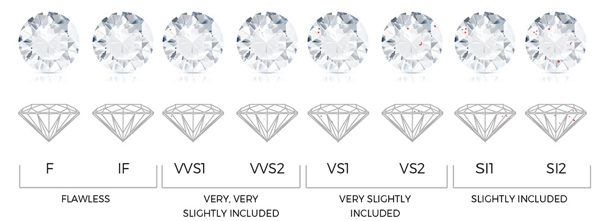

Figure 2. Classification of Diamonds by Clarity

- **Cut**: Cut is the most important characteristic of the diamond.
  - It determines how the light which enters into the diamond from the above will be reflected back to the eye of observer
  - A perfect cut diamond reflects light to its optimum

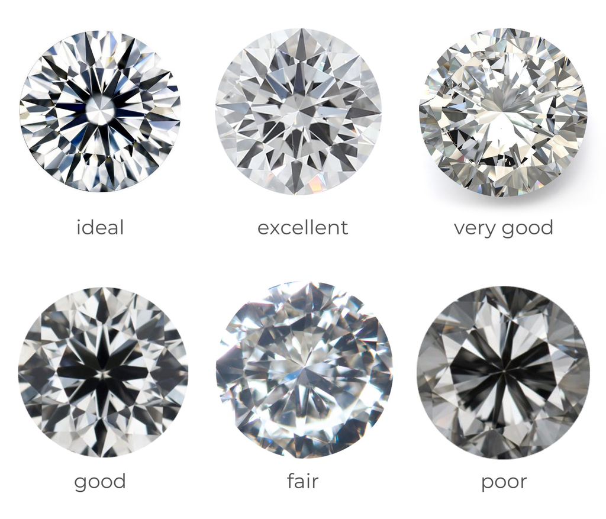

Figure 3. Quality of Cut

# 2 Data and Required Packages

## 2.1 Data Information

In this [assignment](https://mef-bda503.github.io/archive/fall17/files/assignment_diamonds_data.html), there are few objective to improve data analysis skills. These objectives can be listed as follow:

1. To provide useful exploratory data analysis (EDA)
2. To present a model for estimation of the diamond price

To fulfill these objectives, (i) data is analyzed and prepared for the analysis, (ii) the meaningful EDA is presented by using some useful packages such as `ggplot2`, `dplyr`, `tidyverse` etc.

```r
library(ggplot2)
library(dplyr)
library(tidyverse)
library(tm)
library(knitr)
library(tm)
library(kableExtra)
```

The dataset in this analysis is obtained from the `ggplot2` packages. Before the load this data set. By using `?diamonds` we can obtain information about this dataset. This data set contains more than 50.000 round cut diamonds, whose features like are located in this data set. There are 53940 rows and 10 variables. By using this `glimpse()` function, we obtain these variables.

```r
#while we load ggplot2 package, we get directly diamonds dataset by following line
diamonds
```

```r
#variables of the dataset
diamonds %>%
  glimpse()
```

```
## Rows: 53,940
## Columns: 10
## $ carat   <dbl> 0.23, 0.21, 0.23, 0.29, 0.31, 0.24, 0.24, 0.26, 0.22, 0.23,...
## $ cut     <ord> Ideal, Premium, Good, Premium, Good, Very Good, Very Good, ...
## $ color   <ord> E, E, E, I, J, J, I, H, E, H, J, J, F, J, E, E, I, J, J, J,...
## $ clarity <ord> SI2, SI1, VS1, VS2, SI2, VVS2, VVS1, SI1, VS2, VS1, SI1, VS...
## $ depth   <dbl> 61.5, 59.8, 56.9, 62.4, 63.3, 62.8, 62.3, 61.9, 65.1, 59.4,...
## $ table   <dbl> 55, 61, 65, 58, 58, 57, 57, 55, 61, 61, 55, 56, 61, 54, 62,...
## $ price   <int> 326, 326, 327, 334, 335, 336, 336, 337, 337, 338, 339, 340,...
## $ x       <dbl> 3.95, 3.89, 4.05, 4.20, 4.34, 3.94, 3.95, 4.07, 3.87, 4.00,...
## $ y       <dbl> 3.98, 3.84, 4.07, 4.23, 4.35, 3.96, 3.98, 4.11, 3.78, 4.05,...
## $ z       <dbl> 2.43, 2.31, 2.31, 2.63, 2.75, 2.48, 2.47, 2.53, 2.49, 2.39,...
```

**Price**: price in US dollars ($326–$18,823)  
**Carat**: weight of the diamond (0.2–5.01)  
**Cut**: quality of the cut (Fair, Good, Very Good, Premium, Ideal)  
**Color**: diamond color, from D (best) to J (worst)  
**Clarity**: a measurement of how clear the diamond is I1 (worst), SI2, SI1, VS2, VS1, VVS2, VVS1, IF (best)  
**x**: length in mm (0–10.74)  
**y**: width in mm (0–58.9)  
**z**: depth in mm (0–31.8)  
**Depth**: total depth percentage = z / mean(x, y) = 2 * z / (x + y) (43–79)  
**Table**: width of top of diamond relative to widest point (43–95)

## 2.2 Data Preprocessing

In the previous section, detailed information about investigated dataset is presented. In this section, the data is analyzed or pre-processed before the detailed analyses.

```r
#to control NA values in the dataset
sum(any(is.na(diamonds)))
```

```
## [1] 0
```

When we check the dataset, there is 0 NA value. This means that there is no missing value in any row or column.

```r
sum(as.numeric(duplicated(diamonds)))
```

```
## [1] 146
```

```r
#taking only unique rows form the data set
diamonds <- unique(diamonds)
#control of the duplicated lines after removing of the duplicated lines
sum(as.numeric(duplicated(diamonds)))
```

```
## [1] 0
```

After the usage of the unique function there is no duplicated line. After this process, we have 53794 rows and 10 columns. The rows show that the number of trials, whereas, the columns give the number of variables/features in the dataset. After this process, we can use `summary()` function and `head()` function to get more information about the dataset.

```r
summary(diamonds) # summary of each variable in the dataset
```

```
##      carat               cut        color        clarity          depth
##  Min.   :0.2000   Fair     : 1598   D: 6755   SI1    :13032   Min.   :43.00
##  1st Qu.:0.4000   Good     : 4891   E: 9776   VS2    :12229   1st Qu.:61.00
##  Median :0.7000   Very Good:12069   F: 9520   SI2    : 9150   Median :61.80
##  Mean   :0.7978   Premium  :13748   G:11262   VS1    : 8156   Mean   :61.75
##  3rd Qu.:1.0400   Ideal    :21488   H: 8272   VVS2   : 5056   3rd Qu.:62.50
##  Max.   :5.0100                     I: 5407   VVS1   : 3647   Max.   :79.00
##                                     J: 2802   (Other): 2524
##      table           price             x                y
##  Min.   :43.00   Min.   :  326   Min.   : 0.000   Min.   : 0.000
##  1st Qu.:56.00   1st Qu.:  951   1st Qu.: 4.710   1st Qu.: 4.720
##  Median :57.00   Median : 2401   Median : 5.700   Median : 5.710
##  Mean   :57.46   Mean   : 3933   Mean   : 5.731   Mean   : 5.735
##  3rd Qu.:59.00   3rd Qu.: 5327   3rd Qu.: 6.540   3rd Qu.: 6.540
##  Max.   :95.00   Max.   :18823   Max.   :10.740   Max.   :58.900
##
##        z
##  Min.   : 0.000
##  1st Qu.: 2.910
##  Median : 3.530
##  Mean   : 3.539
##  3rd Qu.: 4.030
##  Max.   :31.800
##
```

```r
head(diamonds) #first 6 rows of the data
```

```
## # A tibble: 6 x 10
##   carat cut       color clarity depth table price     x     y     z
##   <dbl> <ord>     <ord> <ord>   <dbl> <dbl> <int> <dbl> <dbl> <dbl>
## 1 0.23  Ideal     E     SI2      61.5    55   326  3.95  3.98  2.43
## 2 0.21  Premium   E     SI1      59.8    61   326  3.89  3.84  2.31
## 3 0.23  Good      E     VS1      56.9    65   327  4.05  4.07  2.31
## 4 0.290 Premium   I     VS2      62.4    58   334  4.2   4.23  2.63
## 5 0.31  Good      J     SI2      63.3    58   335  4.34  4.35  2.75
## 6 0.24  Very Good J     VVS2     62.8    57   336  3.94  3.96  2.48
```

We also control the negative price values in the data set.

```r
diamonds %>%
  filter(price <= 0) %>%
  summarise(NegativePrice = n())
```

```
## # A tibble: 1 x 1
##   NegativePrice
##           <int>
## 1             0
```

Logically, price should be greater than zero. For this reason, we check dataset to control negative price values. According to the results there is no negative price value. This is the expected situation.

# 3 Exploratory Data Analysis

After the pre-processing of the data, we make EDA for the `diamonds` dataset by using different variables.

## 3.1 Quality of Cut

As we mentioned before, cut is one of the most important feature of diamonds. In this data set, quality of cut is given as categorical variables. Fair is the lowest quality, whereas, ideal is the highest quality. For this reason, to examine diamond dataset by using this feature, first I illustrate the number of trials grouped according to the cut feature.

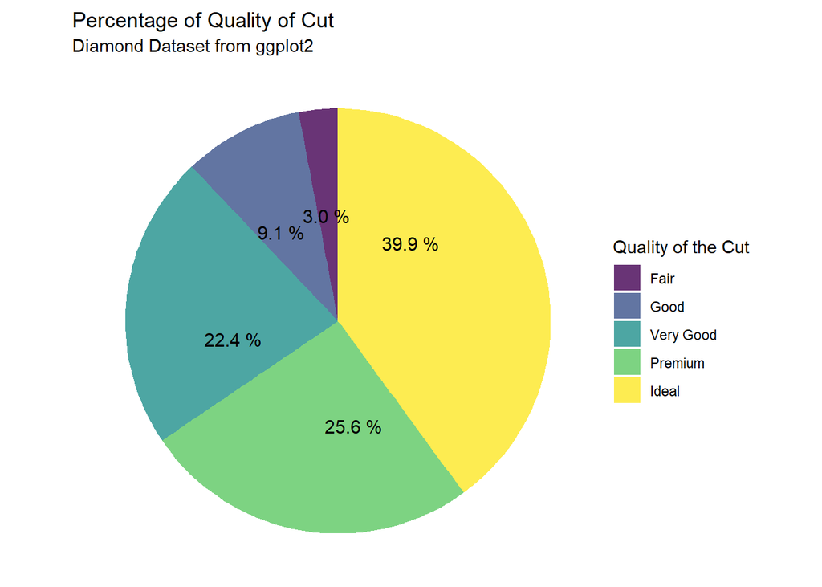

```r
diamonds %>%
  #mutate(cut = factor(cut)) %>%
  group_by(cut) %>%
  summarise(count = n()) %>%
  mutate(percentage = 100*count/sum(count)) %>%

ggplot(., aes(x = '', y = count, fill = cut)) +
  geom_bar(width = 1, stat = "identity", alpha = 0.8) +
  coord_polar("y") +
  theme_void() +
  theme(plot.title = element_text(vjust = 0.5)) +
  geom_text(aes(label = paste(format(percentage,digits=2), "%")), size=4, color = "black", position = position_stack(vjust = 0.3)) +
  labs(title = "Percentage of Quality of Cut ",
       subtitle = st,
       fill = "Quality of the Cut")
```

The pie chart illustrates that, most of the diamonds are cut as ideal form. Moreover, percentage of premium and very good are almost equal. On the other hand, there is a little fair cutting type.

```r
diamonds %>%
  group_by(cut) %>%
  summarise(cut_count = n(),
            MinPrice = min(price),
            AveragePrice = mean(price),
            MaxPrice = max(price)) %>%
  #mutate(percentage = 100*count/sum(count)) %>%
  arrange(desc(cut_count)) %>%
  kable(col.names = c("Cut", "Number of Cut Quality", "Minimum Price", "Average Price", "Maximum Price")) %>%
  kable_minimal(full_width = F)
```

| Cut | Number of Cut Quality | Minimum Price | Average Price | Maximum Price |
| --- | --- | --- | --- | --- |
| Ideal | 21488 | 326 | 3462.750 | 18806 |
| Premium | 13748 | 326 | 4583.502 | 18823 |
| Very Good | 12069 | 336 | 3981.016 | 18818 |
| Good | 4891 | 327 | 3919.121 | 18788 |
| Fair | 1598 | 337 | 4341.954 | 18574 |

More information about cut type can be obtained by analyzing the above table. While, the pie chart presents the percentage of the dataset according to the cut type, the Above table shows the number of trial with cut type. Furthermore, the minimum, average and maximum prices are addressed in this table. Although the most popular cutting type is Ideal cut, its price is not the highest one. According to the average prices, the most expensive diamonds are belongs to Premium.

## 3.2 Number of Colors

Colors are the another imporant feature of the diamonds and also it affects the price of the diamonds. For this reason, in this data set, colors are also investigated. First, according to trials, we can group according to the color. After this grouping process we can number of diamonds with this group.

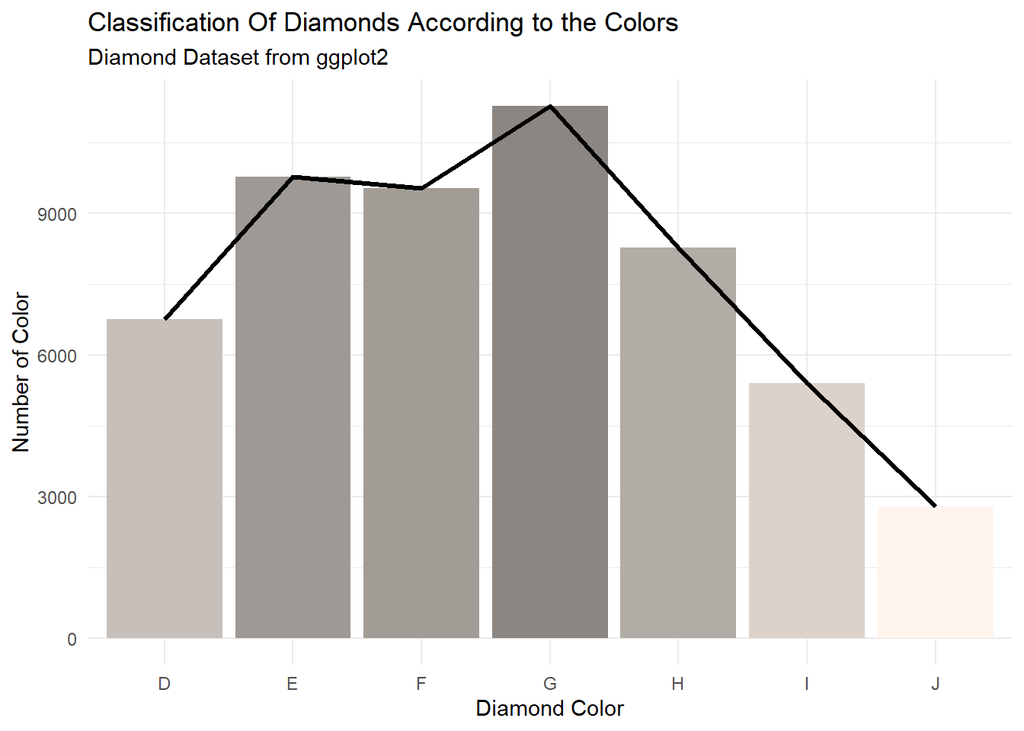

```r
diamonds %>%
  group_by(color)%>%
  summarise(count = n()) %>%

  ggplot(., aes(x=color, y = count, fill = count)) +
  geom_col() +
  scale_fill_gradient("count", low="seashell", high="seashell4") +
  #geom_line(aes(x=color, y=count), color = "black") +
  geom_line(aes(y = count), size = 1.2, color="black", group = 1) +
  theme_minimal() +
  theme(legend.position = "none") +
  labs(title = "Classification Of Diamonds According to the Colors",
       subtitle = st,
       x = "Diamond Color",
       y = "Number of Color")
```

The bar chart illustrates that there is at most G color diamond, whereas, there is at least J color. We can obtain exact value of each color in data set by using below table.

```r
diamonds %>%
  group_by(color)%>%
  summarise(color_count = n(),
            MinPrice = min(price),
            AveragePrice = mean(price),
            MaxPrice = max(price)) %>%
  arrange(desc(color_count)) %>%
  kable(col.names = c("Color", "Count","Minimum Price", "Average Price", "Maximum Price")) %>%
  kable_minimal(full_width = F)
```

| Color | Count | Minimum Price | Average Price | Maximum Price |
| --- | --- | --- | --- | --- |
| G | 11262 | 354 | 4001.352 | 18818 |
| E | 9776 | 326 | 3079.608 | 18731 |
| F | 9520 | 342 | 3726.750 | 18791 |
| H | 8272 | 337 | 4482.855 | 18803 |
| D | 6755 | 357 | 3174.441 | 18693 |
| I | 5407 | 334 | 5081.751 | 18823 |
| J | 2802 | 335 | 5326.415 | 18710 |

According to the diamond information given above D-F color interval is the highest purity. Then, G-F color scale follow. At least, K color takes place. Results illustrates that the number of G color is the highest. The most beautiful color, i.e., actually colorless, is D-F. Although the D is close to bottom of the table, E and F take place in the second and third places of the table. Moreover, by using this table output, we can obtain minimum,maximum and average prices and compare the price of diamonds with each other by using color classification.

## 3.3 Clarity

Clarity gives information about diamonds whether it contains stain or not. In this report, to find clarity classification of the data set, a kind of scatter plot is used.

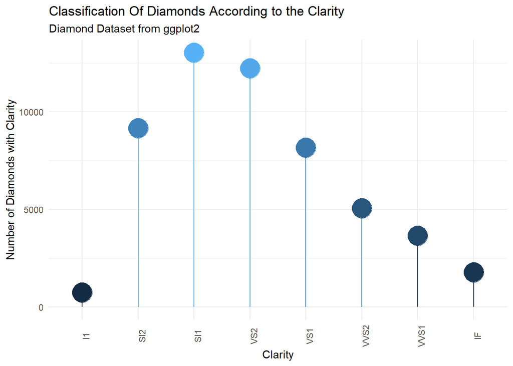

```r
diamonds %>%
  mutate(clarity = factor(clarity)) %>%
  group_by(clarity) %>%
  summarise(clarity_count = n()) %>%

  ggplot(.,aes(x=clarity, y = clarity_count, color= clarity_count)) +
    geom_point(size=9) +
    geom_segment(aes(x=clarity,
                     xend=clarity,
                     y=0,
                     yend=clarity_count))+
    scale_fill_gradient("clarity_count", low="pink", high="pink2") +
    theme_minimal() +
    theme(axis.text.x = element_text(angle = 90), legend.position = "none")+
        labs(title = "Classification Of Diamonds According to the Clarity",
         subtitle = st,
         x = "Clarity",
         y = "Number of Diamonds with Clarity")
```

According to the results,

- The most of the data is occurred form the SI1 clarity type, VS2 and SI2 follow SI1, respectively. These clarity classes are worse when we compare the other clarity classes.
- The best type of clarity, IF, takes place in the at the second place from the last.

To get more clear analysis, the following table, which shows the number of diamonds according to clarity, can be analyzed. Moreover, the minimum, maximum, and average prices can be also obtained.

```r
diamonds %>%
  mutate(clarity = factor(clarity)) %>%
  group_by(clarity) %>%
  summarise(clarity_count = n(),
            MinPrice = min(price),
            AveragePrice = mean(price),
            MaxPrice = max(price)) %>%
  arrange(desc(clarity_count)) %>%
  kable(col.names = c("Clarity", "Count","Minimum Price", "Average Price", "Maximum Price")) %>%
  kable_minimal(full_width = F)
```

| Clarity | Count | Minimum Price | Average Price | Maximum Price |
| --- | --- | --- | --- | --- |
| SI1 | 13032 | 326 | 3996.165 | 18818 |
| VS2 | 12229 | 334 | 3927.742 | 18823 |
| SI2 | 9150 | 326 | 5057.455 | 18804 |
| VS1 | 8156 | 327 | 3841.611 | 18795 |
| VVS2 | 5056 | 336 | 3286.532 | 18768 |
| VVS1 | 3647 | 336 | 2526.603 | 18777 |
| IF | 1784 | 369 | 2870.570 | 18806 |
| I1 | 740 | 345 | 3925.276 | 18531 |

## 3.4 Carat

Carat has two meanings: (i) the purity of the diamonds and (ii) the weight of the diamonds. In this data set, the carat illustrates the weight of the carat. To see the most used carat, the number of data is group according to the carat variable.

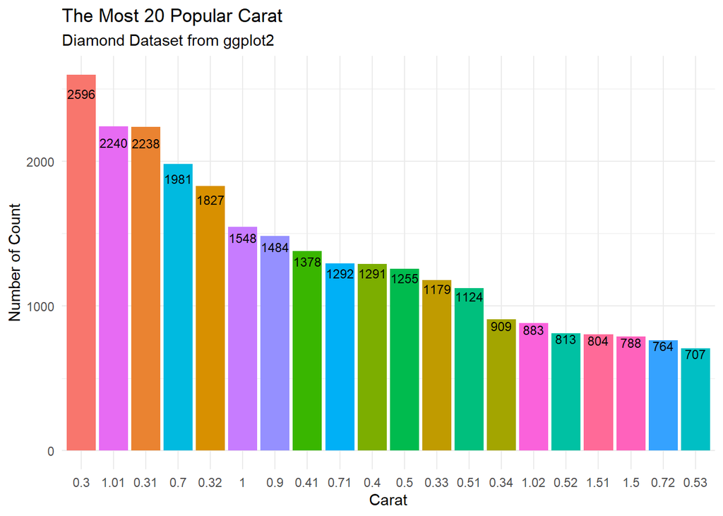

```r
diamonds %>%
  mutate(carat = factor(carat)) %>%
  group_by(carat) %>%
  summarise(carat_count = n())%>%
  arrange(desc(carat_count)) %>%
  head(20) %>%
  ggplot(., aes(y=carat_count, x = reorder(carat, -carat_count), fill= carat)) +
  geom_col() +
  geom_text(aes(label = carat_count), size=3, color = "black", position = position_stack(vjust = 0.95)) +
  theme_minimal() +
  theme(legend.position = "none") +
  labs(title = "The Most 20 Popular Carat",
       subtitle = st,
       x = "Carat",
       y = "Number of Count")
```

In the bar chart, there are the most 20 popular or preferable carat of diamonds are present.

- According to the data set, the most preferable carat is 0.3 carat.

However, there are carats which are more than twenty. To see all carat according to the count, following table can be analyzed. In addition to the number of diamonds according to the carat classification, the price intervals and average price also can be investigated.

```r
diamonds %>%
  mutate(carat = factor(carat)) %>%
  group_by(carat) %>%
  summarise(carat_count = n(),
            inPrice = min(price),
            AveragePrice = mean(price),
            MaxPrice = max(price))%>%
  arrange(desc(carat_count)) %>%
  kable(col.names = c("Carat", "Number of Carats","Minimum Price", "Average Price", "Maximum Price")) %>%
  kable_styling("striped", full_width = T) %>%
  scroll_box(width = "100%", height = "300px")
```

| Carat | Number of Carats | Minimum Price | Average Price | Maximum Price |
| --- | --- | --- | --- | --- |
| 0.3 | 2596 | 339 | 680.6367 | 2366 |
| 1.01 | 2240 | 2017 | 5507.1902 | 16234 |
| 0.31 | 2238 | 335 | 708.1997 | 1917 |
| 0.7 | 1981 | 945 | 2516.0717 | 5539 |
| 0.32 | 1827 | 345 | 719.1916 | 1715 |
| 1 | 1548 | 1681 | 5247.6034 | 16469 |
| 0.9 | 1484 | 1599 | 3939.5889 | 9182 |
| 0.41 | 1378 | 467 | 973.0530 | 1745 |
| 0.71 | 1292 | 1305 | 2673.8893 | 5019 |
| 0.4 | 1291 | 484 | 933.0077 | 1908 |
| 0.5 | 1255 | 584 | 1504.3841 | 3378 |
| 0.33 | 1179 | 366 | 765.1747 | 1389 |
| 0.51 | 1124 | 826 | 1623.9858 | 4368 |
| 0.34 | 909 | 413 | 755.8086 | 2346 |
| 1.02 | 883 | 2344 | 5598.4632 | 17100 |
| 0.52 | 813 | 870 | 1656.4785 | 3373 |
| 1.51 | 804 | 3497 | 10552.0211 | 18806 |
| 1.5 | 788 | 2964 | 10076.1916 | 18691 |
| 0.72 | 764 | 945 | 2705.7788 | 5086 |
| 0.53 | 707 | 844 | 1685.5248 | 3827 |
| 0.42 | 704 | 552 | 994.4545 | 1722 |
| 0.38 | 670 | 497 | 904.4418 | 1992 |
| 0.35 | 663 | 409 | 799.5098 | 1672 |
| 1.2 | 644 | 2360 | 6684.7376 | 16256 |
| 0.54 | 624 | 935 | 1704.3317 | 4042 |
| 0.36 | 570 | 410 | 781.4667 | 1718 |
| 0.91 | 570 | 1570 | 3981.1561 | 9636 |
| 1.03 | 522 | 1262 | 5583.8966 | 17590 |
| 0.55 | 496 | 959 | 1725.4415 | 3509 |
| 0.56 | 492 | 953 | 1831.9980 | 4632 |

[output cut: 243 more lines]

Up until now, there are most important features of the diamonds are presented as a count analysis. After that point, relationship between variables and prices are illustrated.

## 3.6 Price vs Variables

### 3.6.1 Price and Clarity Analysis

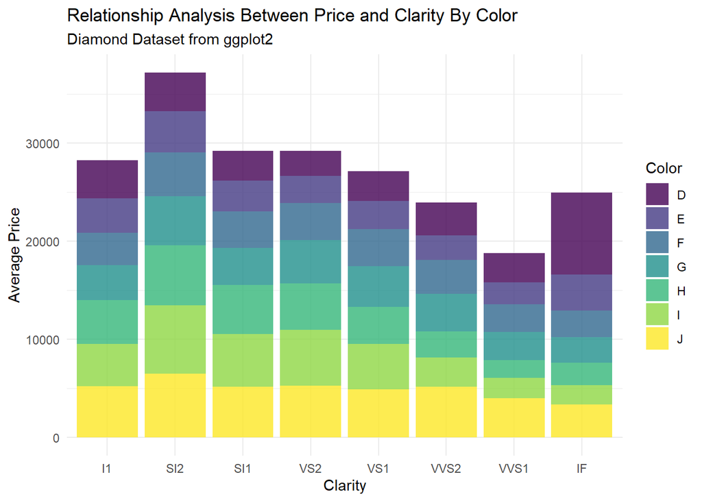

```r
diamonds %>%
  group_by(clarity, color) %>%
  summarise(MeanPrice = mean(price)) %>%

  ggplot(aes(x=clarity, y = MeanPrice, fill = color)) +
  geom_col(alpha = 0.8) +
  theme_minimal() +
  labs(title = "Relationship Analysis Between Price and Clarity By Color",
       subtitle = st,
       x = "Clarity",
       y = "Average Price",
       fill = "Color")
```

## 3.7 Price Group Analysis

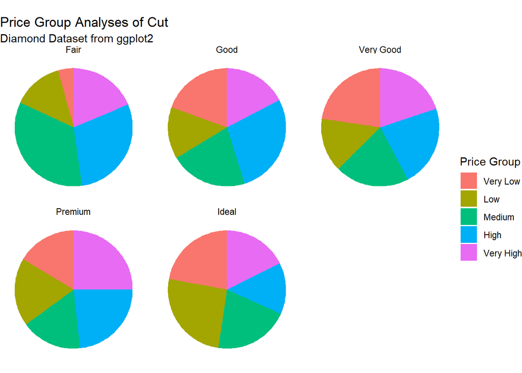

```r
quant = quantile(diamonds$price, seq(0, 1, 0.2))

diamonds_price_group <- diamonds %>%
  mutate(price_group = case_when(
    price < quant[2] ~ "Very Low",
    price < quant[3] ~ "Low",
    price < quant[4] ~ "Medium",
    price < quant[5] ~ "High",
    TRUE ~ "Very High"
  )) %>%
  mutate(price_group = factor(price_group, levels = c("Very Low", "Low", "Medium", "High", "Very High")))

diamonds_price_group %>%
  group_by(cut, price_group) %>%
  summarise(count=n()) %>%
  mutate(percentage = 100 * count / sum(count)) %>%
  ggplot(., aes(x = '', y = count, fill = price_group)) +
  geom_bar(width = 1, stat = "identity", position = "fill") +
  coord_polar("y") +
  theme_void() +
  theme(plot.title = element_text(vjust = 0.5)) +
  facet_wrap(~cut) +
  labs(title = "Price Group Analyses of Cut",
       subtitle = st,
       fill = "Price Group")
```

```r
diamonds_price_group %>%
  group_by(cut, price_group) %>%
  summarise(count=n()) %>%
  mutate(percentage = 100 * count / sum(count)) %>%
  select(cut, price_group, count)%>%
  pivot_wider(id_cols = cut, names_from = price_group, values_from = count) %>%
  kable(col.names = c("Cut", "Very Low","Low", "Medium", "High", "Very High"))%>%
  kable_minimal(full_width = F)
```

| Cut | Very Low | Low | Medium | High | Very High |
| --- | --- | --- | --- | --- | --- |
| Fair | 68 | 221 | 546 | 465 | 298 |
| Good | 953 | 694 | 1035 | 1361 | 848 |
| Very Good | 2735 | 1783 | 2453 | 2699 | 2399 |
| Premium | 2247 | 2571 | 2294 | 3204 | 3432 |
| Ideal | 4745 | 5498 | 4433 | 3028 | 3784 |

## 3.8 Price Histogram

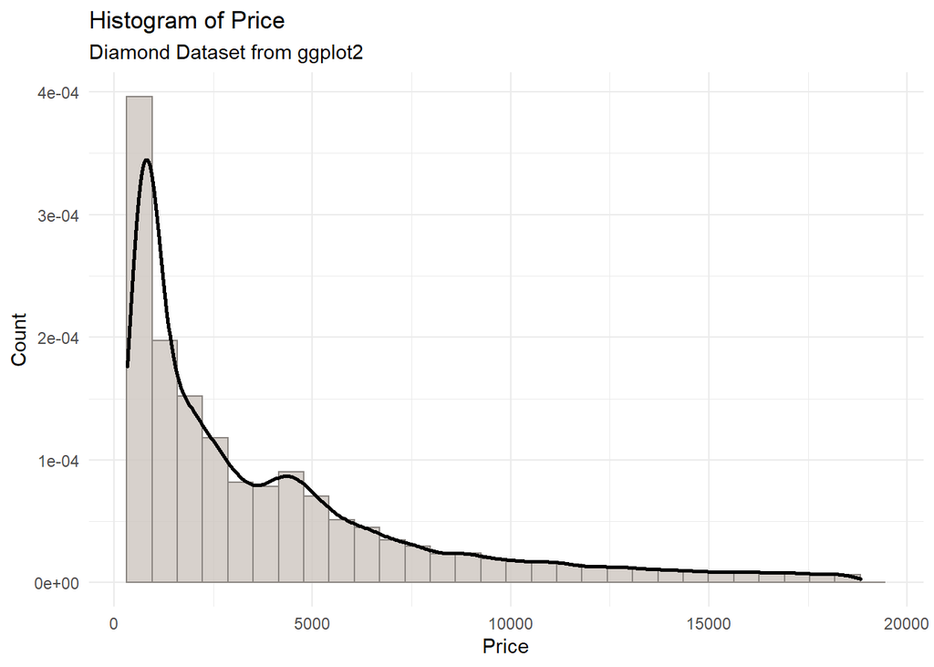

```r
diamonds %>%
  ggplot(aes(x=price)) +
  geom_histogram(aes(y=..density..), position="identity", alpha=0.8, fill = "seashell3", color="seashell4") +
  geom_density(alpha=1, size = 1)+
  theme_minimal() +
  labs(title = "Histogram of Price",
       subtitle = st,
       x = "Price",
       y = "Count")
```

The histogram shows that the price in diamonds dataset is right skewed.

# 4 Predicting Model

There are categorical variables. For this reason we do not use PCA test to find relationship. The other classification methods such as MSC, K-Means, etc can be used.

Before make a classification for this dataset, we need additional packages:

1. data.table: for rearrange the dataset to transform categoric variable to numeric variable.
2. rpart: to obtain regressşon tree
3. rpart.plot
4. [rattle](https://www.rdocumentation.org/packages/rattle/versions/5.4.0): provide graphical user interface

```r
library(data.table)
library(rpart)
library(rpart.plot)
library(rattle)
```

## 4.1 Classification Model

The diamonds dataset includes both numeric and categorical variables. For this reason, before the make classification, first the categorical variables should be transformed into numeric variable. To get this purposes, the following codes can be used.

```r
diamonds2 <- setDT(diamonds) # by using setDT function we convert data frame to data table

#cut, clarity, and color are the categorical variable of this dat set. When we translate this variables to numeric and assign them into the variable, we can obtain numeric variables.

diamonds2$cut <- as.numeric(diamonds2$cut)
diamonds2$clarity <- as.numeric(diamonds2$clarity)
diamonds2$color <- as.numeric(diamonds2$color)

#After the transformation, we can check by using typeof() function or we can use function of dplyr() feature which is glimpse()
#glimpse() shows the variables, variables futures and first examples
diamonds2 %>%
  glimpse()
```

```
## Rows: 53,794
## Columns: 10
## $ carat   <dbl> 0.23, 0.21, 0.23, 0.29, 0.31, 0.24, 0.24, 0.26, 0.22, 0.23,...
## $ cut     <dbl> 5, 4, 2, 4, 2, 3, 3, 3, 1, 3, 2, 5, 4, 5, 4, 4, 5, 2, 2, 3,...
## $ color   <dbl> 2, 2, 2, 6, 7, 7, 6, 5, 2, 5, 7, 7, 3, 7, 2, 2, 6, 7, 7, 7,...
## $ clarity <dbl> 2, 3, 5, 4, 2, 6, 7, 3, 4, 5, 3, 5, 3, 2, 2, 1, 2, 3, 3, 3,...
## $ depth   <dbl> 61.5, 59.8, 56.9, 62.4, 63.3, 62.8, 62.3, 61.9, 65.1, 59.4,...
## $ table   <dbl> 55, 61, 65, 58, 58, 57, 57, 55, 61, 61, 55, 56, 61, 54, 62,...
## $ price   <int> 326, 326, 327, 334, 335, 336, 336, 337, 337, 338, 339, 340,...
## $ x       <dbl> 3.95, 3.89, 4.05, 4.20, 4.34, 3.94, 3.95, 4.07, 3.87, 4.00,...
## $ y       <dbl> 3.98, 3.84, 4.07, 4.23, 4.35, 3.96, 3.98, 4.11, 3.78, 4.05,...
## $ z       <dbl> 2.43, 2.31, 2.31, 2.63, 2.75, 2.48, 2.47, 2.53, 2.49, 2.39,...
```

Through the above transformation, the all variables are obtained as numeric.

By using correlation function, we can obtain distance matrix for the dataset. In this dataset, we try to estimate price for this reason to make classification and get distance matrix, the price variable is removed from the data set by using data.table function.

```r
diamonds_dist <- 1-cor(diamonds2[,!c("price")])
max(diamonds2[,!c("price")]) # maximum value of the data set without price varible
```

```
## [1] 95
```

```r
min(diamonds2[,!c("price")]) # minimum value of the data set without price variable
```

```
## [1] 0
```

Since the difference between maximum and minimum value in the dataset, we need to scale to prevent domination one of the variables to others.

```r
distance <- cmdscale(diamonds_dist,k=2) #scale process for the data set
colnames(distance) <- c("x","y") # renaming of the columns
distance
```

```
##                   x           y
## carat    0.39800117  0.09420480
## cut     -0.63561444  0.29559959
## color   -0.08633914 -0.02236605
## clarity -0.89637864 -0.29834264
## depth   -0.22790824  0.34572730
## table    0.22605504 -0.71216264
## x        0.41505250  0.07650823
## y        0.40445563  0.07771746
## z        0.40267611  0.14311394
```

Then we can prepare the classification of the variables by using following codes. To get classification, `kmeans()` function is used.

```r
set.seed(15) # to provide getting same classification with random process
cluster<-kmeans(distance,centers=4) # application of k-means algorithm for variables
#cluster

mds_clusters<-data.frame(genre=names(cluster$cluster),cluster_mds=cluster$cluster) %>%
  arrange(cluster_mds,genre)

mds_clusters%>%
  select( cluster_mds) %>%
  kable(col.names = c("Cluster")) %>%
  kable_minimal(full_width = FALSE)
```

|  | Cluster |
| --- | --- |
| color | 1 |
| cut | 1 |
| depth | 1 |
| table | 2 |
| clarity | 3 |
| carat | 4 |
| x | 4 |
| y | 4 |
| z | 4 |

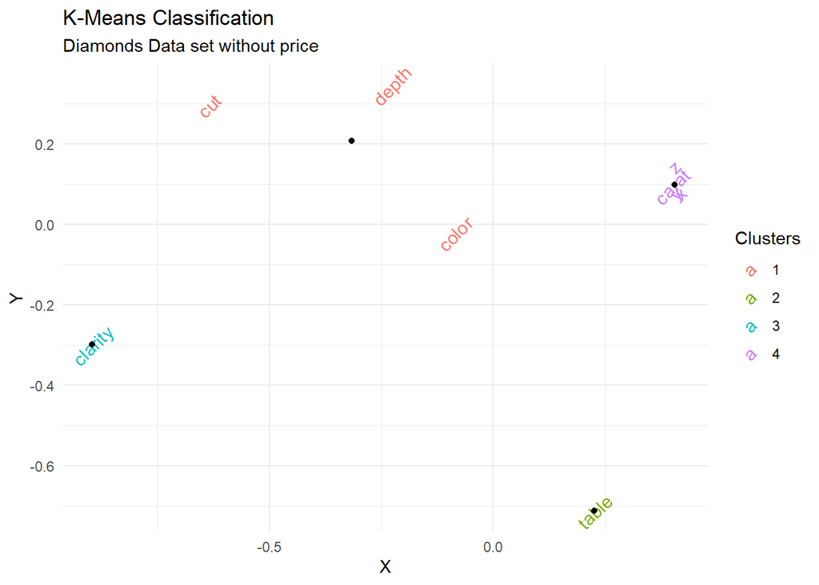

```r
#visualization of the data set
ggplot(data.frame(distance) %>%
         mutate(clusters=as.factor(cluster$cluster),genres=rownames(distance)),aes(x=x,y=y))  +
geom_text(aes(label=genres,color=clusters),angle=45,size=4) +
  geom_point(data=as.data.frame(cluster$centers),aes(x=x,y=y)) +
  theme_minimal() +
  labs(title = "K-Means Classification",
       subtitle = "Diamonds Data set without price",
       x= "X",
       y= "Y",
       color = "Clusters")
```

The table and figure shows the classification of the variables of this data set. According to the results,

- Clarity and Table variables create two different cluster and in these classes there are only one variables.
- Carat, x, y, and z variables form one group, whereas, color,cut and depth creates the other group.

Before, we made classification for the variables in the data set. Moreover, same classification can be prepared for the observations of dataset. For this purpose, first, we need to scaled data frame. Thus, we standardize the data set by using minimum and maximum value of the each column/variable. For this purpose, `sapply()` function is used.

```r
diamonds2scale <- sapply(diamonds2[,-7], function(x) {(x-min(x))/(max(x)-min(x))})

set.seed(15) # to provide getting same classification with random process
cluster<-kmeans(diamonds2scale,centers=8)
#cluster

100*round(1 - (cluster$tot.withinss/cluster$totss), digits = 4)
```

```
## [1] 67.31
```

In the above *k-means* application, we obtain eighth classes to classify dataset. In this trial, we obtain the number of classroom as deterministically, i.e., we set the number of group as eighth. However, by making some interpretations with output of the k-means functions. Thus, the *for loop* is created as foolow, and the outputs are visualized by using `ggplot()` function.In this example, the number of group is determined between 1 to 15.

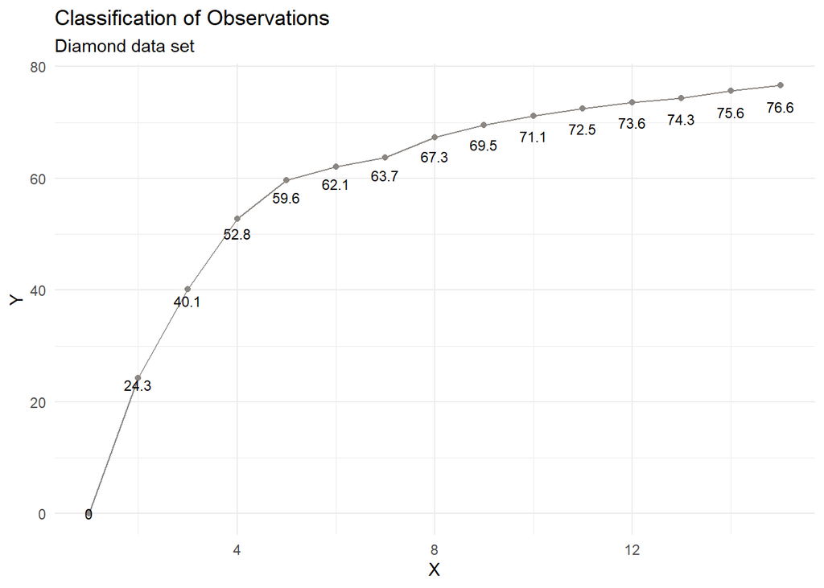

```r
errors = c()
for (i in (1:15)){
  set.seed(15) #provide getting same results with random function
  cluster<-kmeans(diamonds2scale,centers=i) # application of the k-means function with i number of group size
  errors = c(errors, 100*round(1 - (cluster$tot.withinss/cluster$totss), digits = 3)) # calculation of the fulfillment of the clusters to data.
}

errors_df <- data.frame(x=c(1:15), y=errors) # creating data frame with errors.

ggplot(errors_df, aes(x=x, y=y)) +
  geom_point(color = "seashell4") +
  geom_line(color="seashell4") +
  geom_text(aes(label = errors), size=3, color = "black", position = position_stack(vjust = 0.95))+
  theme_minimal() +
  labs(title = "Classification of Observations",
       subtitle = "Diamond data set",
       x = "X",
       y = "Y")
```

```r
## 508 dersindeki gibi lineer regresyonda önceki assumptionları kontrol edeceğiz.
## modeli kuaracağız.

cor(diamonds2) #korelasyon
```

```
##               carat         cut       color     clarity       depth      table
## carat    1.00000000 -0.13337592  0.29101906 -0.35228796  0.02786089  0.1810911
## cut     -0.13337592  1.00000000 -0.02016199  0.18832727 -0.21707757 -0.4337004
## color    0.29101906 -0.02016199  1.00000000  0.02554199  0.04757187  0.0261017
## clarity -0.35228796  0.18832727  0.02554199  1.00000000 -0.06729192 -0.1600003
## depth    0.02786089 -0.21707757  0.04757187 -0.06729192  1.00000000 -0.2976691
## table    0.18109111 -0.43370042  0.02610170 -0.16000033 -0.29766912  1.0000000
## price    0.92154832 -0.05224145  0.17182504 -0.14614893 -0.01104752  0.1265661
## x        0.97537964 -0.12430347  0.26987642 -0.37163563 -0.02534832  0.1948549
## y        0.95190841 -0.12023286  0.26315277 -0.35804833 -0.02938912  0.1832310
## z        0.95354199 -0.14793992  0.26782512 -0.36656803  0.09475725  0.1502703
##               price           x           y           z
## carat    0.92154832  0.97537964  0.95190841  0.95354199
## cut     -0.05224145 -0.12430347 -0.12023286 -0.14793992
## color    0.17182504  0.26987642  0.26315277  0.26782512
## clarity -0.14614893 -0.37163563 -0.35804833 -0.36656803
## depth   -0.01104752 -0.02534832 -0.02938912  0.09475725
## table    0.12656609  0.19485492  0.18323095  0.15027032
## price    1.00000000  0.88450404  0.86539524  0.86120773
## x        0.88450404  1.00000000  0.97459223  0.97068620
## y        0.86539524  0.97459223  1.00000000  0.95184395
## z        0.86120773  0.97068620  0.95184395  1.00000000
```

```r
#plot(diamonds)

# regression <- lm(log(price)~., data = diamonds2)
# summary(regression)
# plot(regression)

gen_regression <- lm(price~carat+color+cut+clarity+table+depth, data = diamonds)
summary(gen_regression)
```

```
##
## Call:
## lm(formula = price ~ carat + color + cut + clarity + table +
##     depth, data = diamonds)
##
## Residuals:
##      Min       1Q   Median       3Q      Max
## -16854.4   -679.3   -199.9    465.6  10336.0
##
## Coefficients:
##              Estimate Std. Error  t value Pr(>|t|)
## (Intercept)  -914.643    361.829   -2.528   0.0115 *
## carat        8901.861     12.102  735.591  < 2e-16 ***
## color.L     -1910.605     17.733 -107.746  < 2e-16 ***
## color.Q      -629.355     16.128  -39.023  < 2e-16 ***
## color.C      -174.726     15.077  -11.589  < 2e-16 ***
## color^4        18.439     13.846    1.332   0.1830
## color^5       -85.347     13.083   -6.524 6.93e-11 ***
## color^6       -50.979     11.895   -4.286 1.82e-05 ***
## cut.L         610.606     23.046   26.495  < 2e-16 ***
## cut.Q        -325.344     18.433  -17.650  < 2e-16 ***
## cut.C         157.935     15.848    9.966  < 2e-16 ***
## cut^4         -17.619     12.660   -1.392   0.1640
## clarity.L    4207.896     30.891  136.219  < 2e-16 ***
## clarity.Q   -1829.200     28.834  -63.440  < 2e-16 ***
## clarity.C     920.854     24.693   37.292  < 2e-16 ***
## clarity^4    -363.403     19.747  -18.403  < 2e-16 ***
## clarity^5     214.438     16.123   13.300  < 2e-16 ***
## clarity^6       2.690     14.042    0.192   0.8481
## clarity^7     110.472     12.385    8.920  < 2e-16 ***
## table         -25.172      2.986   -8.431  < 2e-16 ***
## depth         -21.620      4.093   -5.282 1.28e-07 ***
## ---
## Signif. codes:  0 '***' 0.001 '**' 0.01 '*' 0.05 '.' 0.1 ' ' 1
##
## Residual standard error: 1156 on 53773 degrees of freedom
## Multiple R-squared:  0.916,  Adjusted R-squared:  0.916
## F-statistic: 2.934e+04 on 20 and 53773 DF,  p-value: < 2.2e-16
```

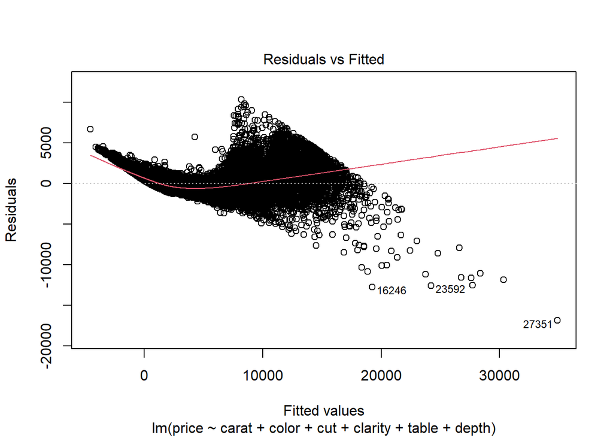

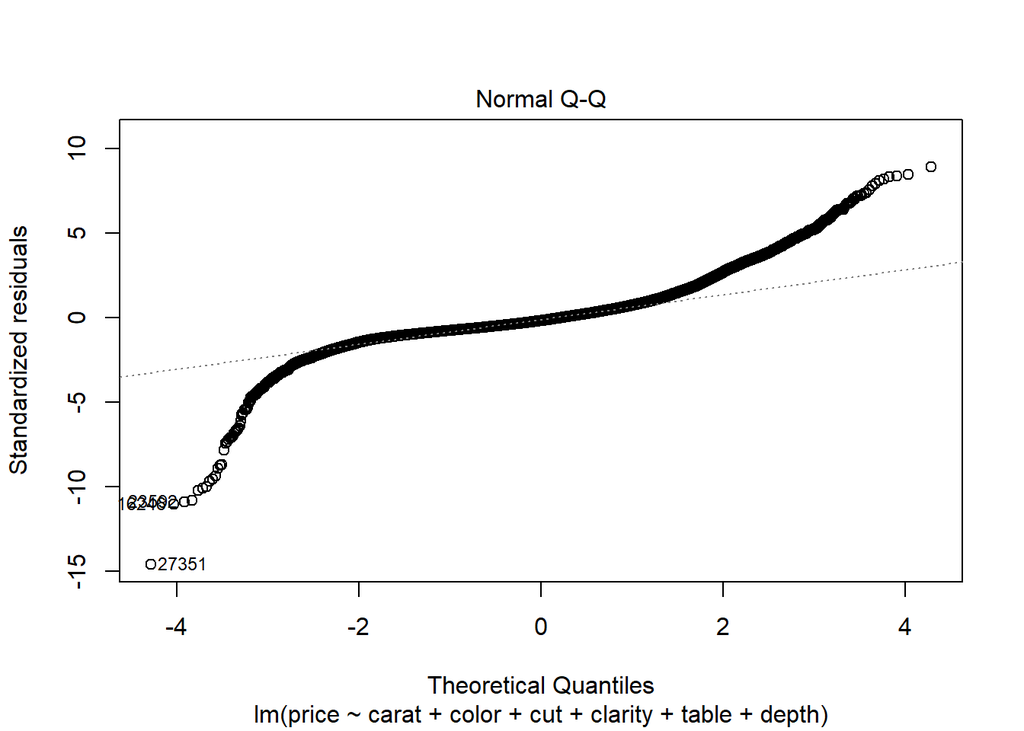

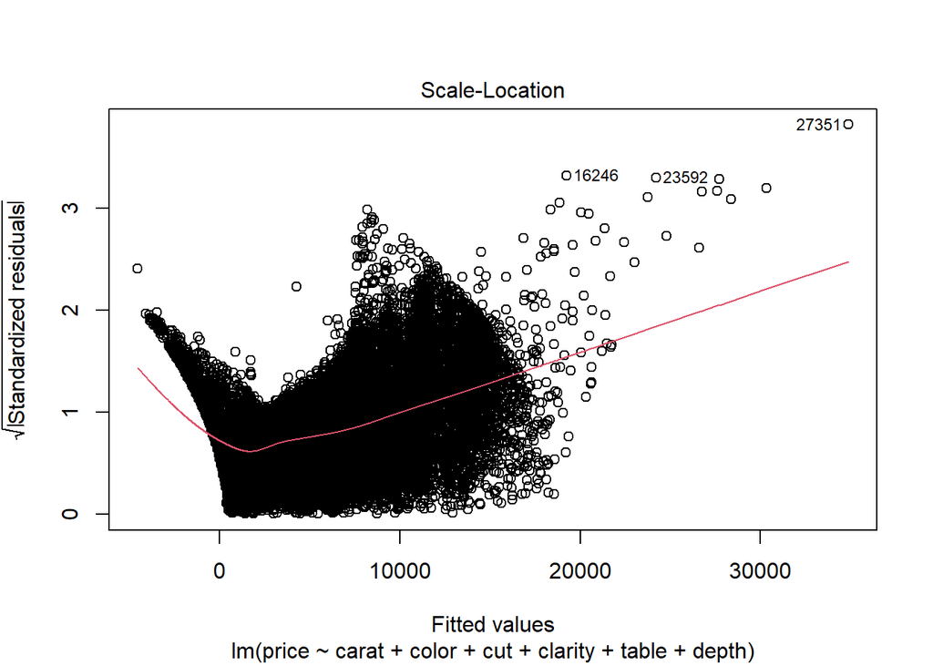

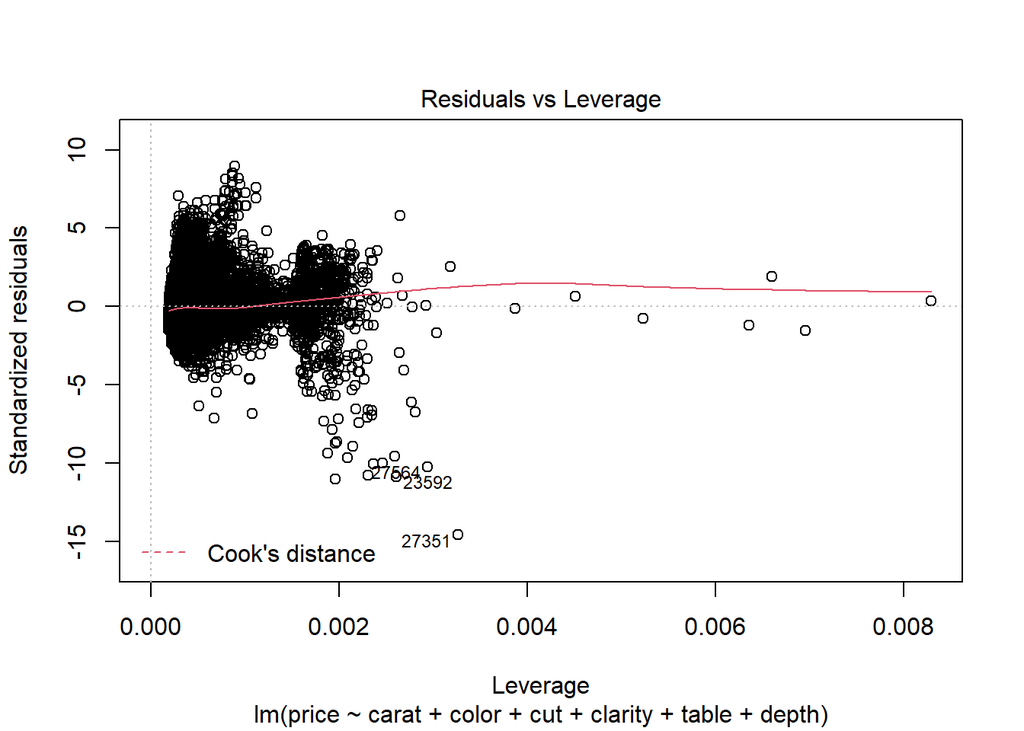

```r
plot(gen_regression)
```